# Coding scheme

Bonan Zhao

9/12/2022

# Experiments overview

Participants had to learn a causal relationship between features of a causal agent (magic egg, the egg) and changes in a causal recipient (a block of segments, sticks) based on several examples in which the two objects interacted. In each example, by clicking a ‘’test’’ button, the agent moves toward the recipient, and the recipient changes into its result form.

See Appendix for a summary of the stimuli.

# Ground truths and alternatives

| Exp. | Ground truth | Alternative |
| --- | --- | --- |
| 1 | stripe(egg) * segment(block) - spot(egg) | stripe(egg) * (segment(block) - spot(egg)) |
| 2 | spot(egg) * segment(block) - stripe(egg) | spot(egg) * (segment(block) - stripe(egg)) |
| 3 | stripe(egg) * segment(block) - spot(egg) | stripe(egg) * (segment(block) - spot(egg)) |
| 4 | spot(egg) * segment(block) - stripe(egg) | spot(egg) * (segment(block) - stripe(egg)) |

# Types of responses

| Type | Definition | Examples |
| --- | --- | --- |
| Ground_truth | equivalent to the ground truth causal relation in each experiment | the length is multiplied by the number of lines and then the number of dots is subtracted |
| Alternative | equivalent to the alternative causal relation in each experiment | the dots subtract from the segments by their number, and the number of lines is multiplied by the amount of segments |
| Comp | unclear or implicit about how two sub causal concepts should be combined | the lines multiply the segments and the dots subtract the segments. |
| Add_2 | add two segments to the recipient | adds 2 segments to the stick only if there are 2 or more stripes on the egg |
| Mult | one feature of the agent object multiplies the recipient object | the number of stripes multiplies the number of segments |
| Subtraction | one feature of the agent object is a subtractor to the recipient object | each spot on the egg takes away one stick |
| Complex | describe the stimuli without generalizing a rule, report a different rule for each observation | 3 dots means the sticks disappear, 2 dots means 2 sticks, 1 dot means add another stick; if there are more lines than dots it will increase in size. |
|  |  | if there are more dots than lines it will decrease in size. an equal number of dots and lines will results in no change |
| Uncertain | not knowing, unsure, or confused about the learning stimuli | i dont have a clue! |

# Appendix: Experiment stimuli

## Experiment 1

**Construct**: First build the `Stripes(A) * Blocks(R)` sub-part, and then re-use it to build the ground truth rule

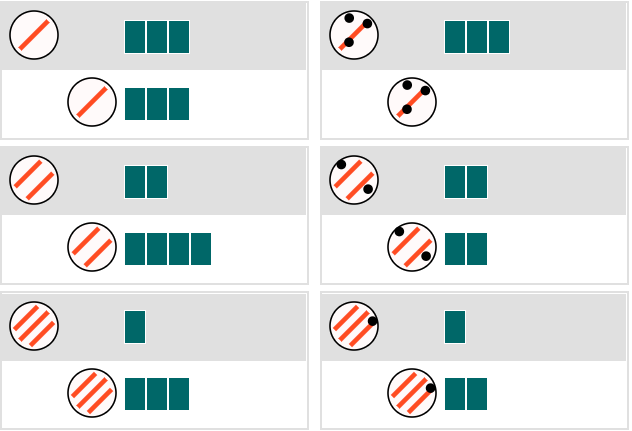

**Deconstruct**: reverse order of the `construct` condition

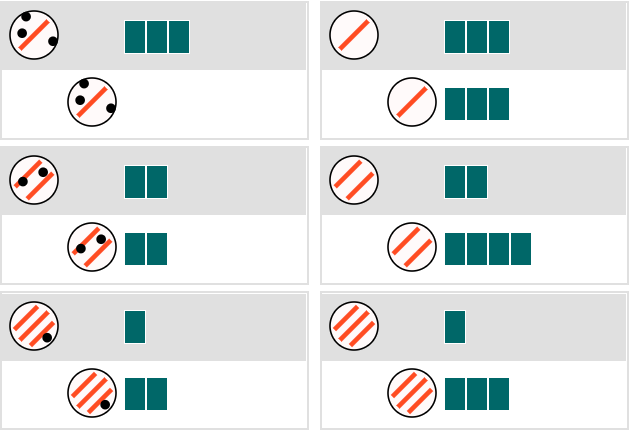

**Combine**: First build the `Stripes(A) * Blocks(R)` sub-part, and then build the `- Dots(A)` sub-part

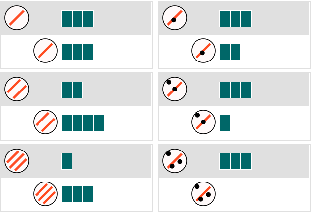

## Experiment 2

Feature counter-balancing of Exp. 1

**Construct**: First build the `Spots(A) * Blocks(R)` sub-part, and then re-use it to build the ground truth rule

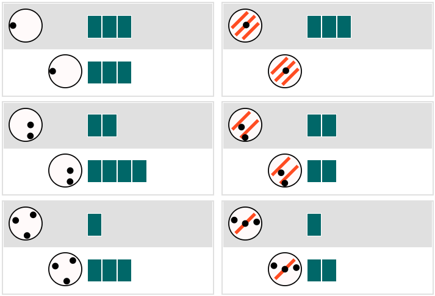

**Deconstruct**: reverse order of the `construct` condition

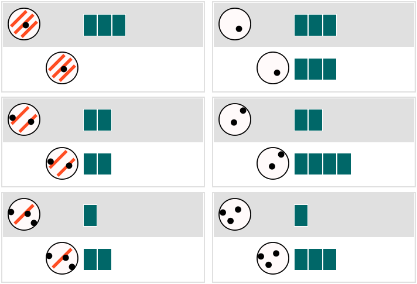

**Combine**: First build the `Spots(A) * Blocks(R)` sub-part, and then build the `- Stripes(A)` sub-part

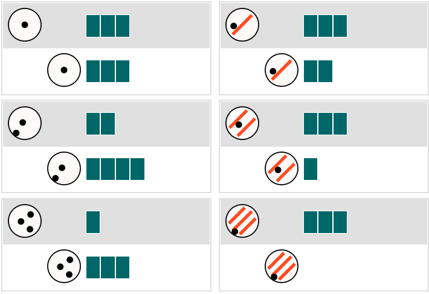

## Experiment 3

**Combine**: First build the `Stripes(A) * Blocks(R)` sub-part, and then build the `- Dots(A)` sub-part

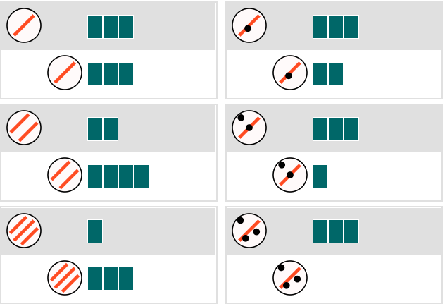

**Flip**: reverse order of the `combine` condition

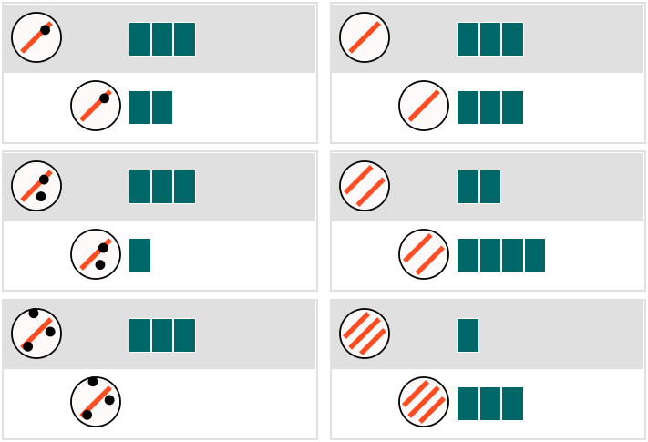

## Experiment 4

Feature counter-balancing of Exp. 3

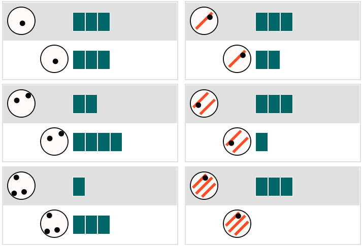

**Flip**: reverse order of the `combine` condition

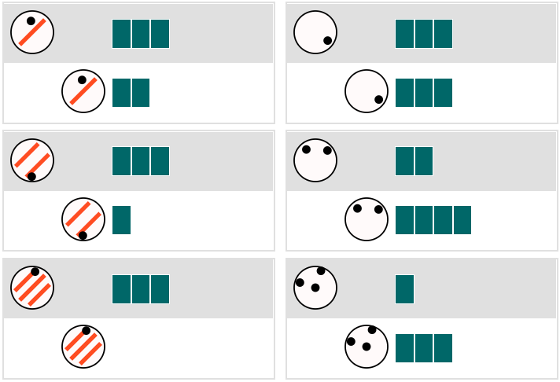